# **Life expectancy prediction based on lifestyle indicators of elderly population using Bayesian inference**

**Determination of the relationship between lifestyle indicators of the elderly population and average life expectancy. Life expectancy prediction using both frequentist and Bayesian inference.**

```python
!pip install pymc3
import pymc3 as pm3
import numpy as np
import pandas as pd
import arviz as az
import matplotlib.pyplot as plt
import plotly.express as px
from sklearn.linear_model import LinearRegression
import seaborn as sns
from statsmodels.stats.multicomp import MultiComparison
%matplotlib inline
from google.colab import drive
drive.mount('/content/drive')
from sklearn.preprocessing import PolynomialFeatures
from sklearn.metrics import mean_squared_error
from sklearn.model_selection import train_test_split
from sklearn import linear_model
```

```python
from sklearn import tree
from sklearn.metrics import mean_absolute_error
from sklearn.model_selection import cross_val_score
from sklearn.model_selection import KFold
from xgboost import XGBRegressor
from sklearn.ensemble import RandomForestRegressor
from sklearn.neighbors import KNeighborsRegressor
```

## Data preperation

Data sourses:

- [Alzheimer's Disease and Healthy Aging Data](https://chronicdata.cdc.gov/Healthy-Aging/Alzheimer-s-Disease-and-Healthy-Aging-Data/hfr9-rurv)
- [U.S. Life Expectancy 1950-2023](https://www.macrotrends.net/countries/USA/united-states/life-expectancy)

```python
life_exp = pd.read_csv('/content/drive/MyDrive/Colab Notebooks/life_expectancy.csv')
health = pd.read_csv('/content/drive/MyDrive/Colab Notebooks/Alzheimer_s_Disease_and_Healthy_Aging_Data.csv')
```

```python
health.columns
```

```
Index(['RowId', 'YearStart', 'YearEnd', 'LocationAbbr', 'LocationDesc',
       'Datasource', 'Class', 'Topic', 'Question', 'Response',
       'Data_Value_Unit', 'DataValueTypeID', 'Data_Value_Type', 'Data_Value',
       'Data_Value_Alt', 'Data_Value_Footnote_Symbol', 'Data_Value_Footnote',
       'Low_Confidence_Limit', 'High_Confidence_Limit', 'Sample_Size',
       'StratificationCategory1', 'Stratification1', 'StratificationCategory2',
       'Stratification2', 'StratificationCategory3', 'Stratification3',
       'Geolocation', 'ClassID', 'TopicID', 'QuestionID', 'ResponseID',
       'LocationID', 'StratificationCategoryID1', 'StratificationID1',
       'StratificationCategoryID2', 'StratificationID2',
       'StratificationCategoryID3', 'StratificationID3', 'Report'],
      dtype='object')
```

```python
life_exp.STATE.unique()
```

```
array(['AL', 'AK', 'AZ', 'AR', 'CA', 'CO', 'CT', 'DE', 'FL', 'GA', 'HI',
       'ID', 'IL', 'IN', 'IA', 'KS', 'KY', 'LA', 'ME', 'MD', 'MA', 'MI',
       'MN', 'MS', 'MO', 'MT', 'NE', 'NV', 'NH', 'NJ', 'NM', 'NY', 'NC',
       'ND', 'OH', 'OK', 'OR', 'PA', 'RI', 'SC', 'SD', 'TN', 'TX', 'UT',
       'VT', 'VA', 'WA', 'WV', 'WI', 'WY'], dtype=object)
```

```python
health.YearStart.unique()
```

```
array([2020, 2017, 2018, 2019, 2015, 2016])
```

Merging health and life ecpectancy data for 2018 and 2019:

```python
health = pd.merge(health[['YearStart','LocationAbbr', 'LocationDesc','Topic','Question', 'Data_Value']][(health.YearStart.isin([2018, 2019])) &
                                                                                      (health.Stratification1=='Overall') &
                                                                                      (health.Stratification2.isna()) &
                                                                                      (health.Topic.isin(['Binge drinking within past 30 days',
                                                                                                          'Diabetes screening within past 3 years', 'Ever had pneumococcal vaccine',
                                                                                                          'Duration of caregiving among older adults', 'Eating 2 or more fruits daily',
                                                                                                          'Obesity', 'Current smoking', 'Cholesterol checked in past 5 years',
                                                                                                          'Intensity of caregiving among older adults', 'Lifetime diagnosis of depression']))],
                        life_exp[['STATE', 'RATE', 'YEAR']][(life_exp.YEAR.isin([2018, 2019]))], left_on=['LocationAbbr','YearStart'],
                                                                                                 right_on=['STATE','YEAR'])
health
```

|  | YearStart | LocationAbbr | LocationDesc | Topic | Question | Data_Value | STATE | RATE | YEAR |
| --- | --- | --- | --- | --- | --- | --- | --- | --- | --- |
| 0 | 2018 | AK | Alaska | Ever had pneumococcal vaccine | Percentage of at risk adults (have diabetes, a... | 49.2 | AK | 78.0 | 2018 |
| 1 | 2018 | AK | Alaska | Obesity | Percentage of older adults who are currently o... | 30.7 | AK | 78.0 | 2018 |
| 2 | 2018 | AK | Alaska | Diabetes screening within past 3 years | Percentage of older adults without diabetes wh... | 66.5 | AK | 78.0 | 2018 |
| 3 | 2018 | AK | Alaska | Binge drinking within past 30 days | Percentage of older adults who reported binge ... | 9.6 | AK | 78.0 | 2018 |
| 4 | 2018 | AK | Alaska | Lifetime diagnosis of depression | Percentage of older adults with a lifetime dia... | 20.0 | AK | 78.0 | 2018 |
| ... | ... | ... | ... | ... | ... | ... | ... | ... | ... |
| 670 | 2019 | WY | Wyoming | Ever had pneumococcal vaccine | Percentage of at risk adults (have diabetes, a... | 59.6 | WY | 77.7 | 2019 |
| 671 | 2019 | WY | Wyoming | Current smoking | Percentage of older adults who have smoked at ... | 16.2 | WY | 77.7 | 2019 |
| 672 | 2019 | WY | Wyoming | Eating 2 or more fruits daily | Percentage of older adults who are eating 2 or... | 34.3 | WY | 77.7 | 2019 |
| 673 | 2019 | WY | Wyoming | Obesity | Percentage of older adults who are currently o... | 32.4 | WY | 77.7 | 2019 |
| 674 | 2019 | WY | Wyoming | Cholesterol checked in past 5 years | Percentage of older adults who had a cholester... | 92.3 | WY | 77.7 | 2019 |

675 rows × 9 columns

```python
health_train = health.pivot_table(index=['LocationDesc', 'YEAR', 'RATE'], values=['Data_Value'], columns=['Topic']).reset_index()
health_train.columns = health_train.columns.to_flat_index()
```

```python
health_train.columns = ['state', 'year', 'life_expect', 'drinking', 'chol_check', 'smoking', 'diabet_screen',
                        'careg_duration', 'veggies', 'pneum_vaccine', 'care_intensity', 'obesity', 'lifetime_depression']
health_train.isna().sum()
```

```
state                   0
year                    0
life_expect             0
drinking                0
chol_check             50
smoking                 0
diabet_screen          47
careg_duration         84
veggies                50
pneum_vaccine           0
care_intensity         84
obesity                 0
lifetime_depression     0
dtype: int64
```

Some columns have prevailing amount of missing values. Let's delete them.

```python
health_train.drop(columns=['careg_duration','care_intensity', 'diabet_screen', 'chol_check'], inplace=True)
health_train.head()
```

|  | state | year | life_expect | drinking | smoking | veggies | pneum_vaccine | obesity | lifetime_depression |
| --- | --- | --- | --- | --- | --- | --- | --- | --- | --- |
| 0 | Alabama | 2018 | 75.1 | 6.8 | 16.4 | NaN | 60.3 | 24.0 | 37.3 |
| 1 | Alabama | 2019 | 75.2 | 6.9 | 17.2 | 28.3 | 58.8 | 22.0 | 36.7 |
| 2 | Alaska | 2018 | 78.0 | 9.6 | 17.4 | NaN | 49.2 | 20.0 | 30.7 |
| 3 | Alaska | 2019 | 77.7 | 10.3 | 14.8 | 36.1 | 54.9 | 16.3 | 33.3 |
| 4 | Arizona | 2018 | 78.7 | 9.3 | 12.5 | NaN | 64.8 | 16.9 | 31.6 |

## Data analysis and statistical tests

```python
potential_predictors = ['life_expect', 'drinking', 'smoking', 'veggies', 'pneum_vaccine','obesity', 'lifetime_depression']
```

Descriptive statistics:

```python
health_train[potential_predictors].describe()
```

|  | life_expect | drinking | smoking | veggies | pneum_vaccine | obesity | lifetime_depression |
| --- | --- | --- | --- | --- | --- | --- | --- |
| count | 99.000000 | 99.000000 | 99.000000 | 49.000000 | 99.000000 | 99.000000 | 99.000000 |
| mean | 78.225253 | 9.408081 | 14.265657 | 36.438776 | 62.894949 | 18.000000 | 33.486869 |
| std | 1.700381 | 1.840013 | 2.776401 | 4.903265 | 3.655758 | 3.291269 | 3.794643 |
| min | 74.400000 | 4.700000 | 6.700000 | 26.300000 | 49.200000 | 11.700000 | 22.800000 |
| 25% | 77.100000 | 8.250000 | 12.550000 | 33.700000 | 60.500000 | 15.400000 | 30.900000 |
| 50% | 78.500000 | 9.300000 | 13.900000 | 36.900000 | 63.700000 | 17.600000 | 33.400000 |
| 75% | 79.450000 | 10.650000 | 16.200000 | 40.200000 | 65.400000 | 20.100000 | 36.500000 |
| max | 81.000000 | 14.800000 | 20.700000 | 45.600000 | 68.900000 | 24.800000 | 42.400000 |

Correlation matrix:

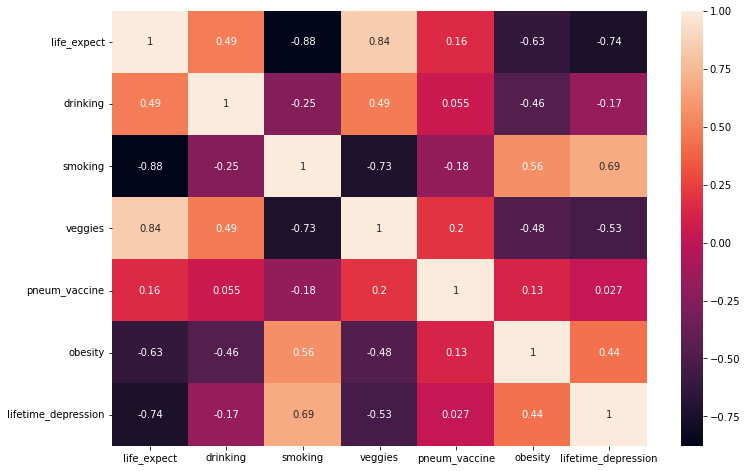

```python
corr_matrix = health_train[potential_predictors].corr()
plt.figure(figsize=(12,8))
sns.heatmap(corr_matrix, annot=True)
plt.show()
```

Correlation coefficient shows a degree to which a pair of variables are linearly related. According to correlation matrix there is a strong corelation between

- life expectancy and smoking,
- life expectancy and veggies,
- life expectancy and obesity,
- life expectancy and lifetime diagnosed depression.

There is also a moderate correlation between binge drinking among seniors and life expectancy and very weak correlation between pneumococcal vaccine and life expectancy.

High correlation does not always indicate a casual relationship but helps to select predictors for building a linear model.

Moderate to high range of correlation between obesity, smoking, small amount of vegetables in the diet (negative correlation) and lifetime depression can be seen.

Filling Nan values in "veggies" column:

```python
potential_predictors.remove('life_expect')

train = health_train.dropna()
x = train['life_expect'].values.reshape(-1, 1)
y = train['veggies']
lin_reg = LinearRegression()
lin_reg.fit(x,y)

def fillna_linear_reg(lin_reg, y, x):
    nan_mask = y.isna()
    pred_y = lin_reg.predict(x.loc[nan_mask].values.reshape(-1, 1))
    y.loc[nan_mask] = pred_y

fillna_linear_reg(
    lin_reg, health_train.loc[:, 'veggies'], health_train.loc[:, 'life_expect']
)
```

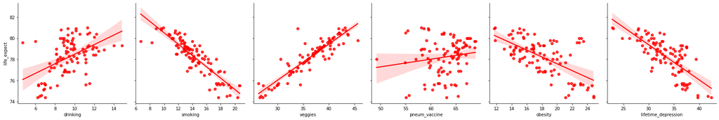

```python
g = sns.PairGrid(health_train, y_vars=['life_expect'], x_vars=potential_predictors, height=4)
g.map(sns.regplot, color='red')
```

Some of the features seem to have linear relationships between them and life expectancy. There are outliers that I don't find posible to remove from data set because of small amount of data and possibly hidden information in the state variable.

For example level of obesity in Oregon, Washington and Utah is one of the highest in US. Meanwhile life expextancy is at a high level in these states.

```python
health_train[(health_train.obesity > 22) & (health_train.life_expect>79)]
```

|  | state | year | life_expect | drinking | smoking | veggies | pneum_vaccine | obesity | lifetime_depression |
| --- | --- | --- | --- | --- | --- | --- | --- | --- | --- |
| 71 | Oregon | 2018 | 79.7 | 9.3 | 14.0 | 40.007143 | 68.9 | 23.5 | 32.6 |
| 72 | Oregon | 2019 | 79.6 | 8.8 | 12.9 | 40.400000 | 66.6 | 22.6 | 30.9 |
| 85 | Utah | 2018 | 79.6 | 4.7 | 8.3 | 39.764296 | 65.1 | 22.9 | 31.5 |
| 91 | Washington | 2018 | 80.0 | 8.7 | 11.3 | 40.735684 | 67.9 | 22.9 | 31.0 |
| 92 | Washington | 2019 | 80.0 | 8.5 | 12.2 | 40.000000 | 67.6 | 23.2 | 30.5 |

### Satistical tests to find out statistically significant differences in life expectancy

Before bulding any models let's test the hypothesis: there is a relationship between life expectancy and US state in 2018 and 2019.

There are 2 main ways to check if the means of a group of samples are different:

1. ANOVA-test checks if there is at least one group with an average that is different from the others;
2. Tukey Test compares the means of each group in pairs and finds means that are significantly different from each other.

Statement of the hypothesis:

- **H0** : average life expectancy in US states does not differ
- **H1** : it differs

Tukey test resultsf for life expectancy in different states:

```python
comp = MultiComparison(health_train['life_expect'], health_train['state'])
result = pd.read_html(comp.tukeyhsd(alpha=0.1).summary().as_html(), header=0, index_col=0)[0].query("reject==True").reset_index()
result.sort_values('meandiff')
```

|  | group1 | group2 | meandiff | p-adj | lower | upper | reject |
| --- | --- | --- | --- | --- | --- | --- | --- |
| 387 | Hawaii | West Virginia | -6.50 | 0.001 | -7.1661 | -5.8339 | True |
| 364 | Hawaii | Mississippi | -6.45 | 0.001 | -7.1161 | -5.7839 | True |
| 190 | California | West Virginia | -6.40 | 0.001 | -7.0661 | -5.7339 | True |
| 167 | California | Mississippi | -6.35 | 0.001 | -7.0161 | -5.6839 | True |
| 832 | New York | West Virginia | -6.15 | 0.001 | -6.8161 | -5.4839 | True |
| ... | ... | ... | ... | ... | ... | ... | ... |
| 26 | Alabama | New York | 5.45 | 0.001 | 4.7839 | 6.1161 | True |
| 708 | Mississippi | Washington | 5.50 | 0.001 | 4.8339 | 6.1661 | True |
| 2 | Alabama | California | 5.70 | 0.001 | 5.0339 | 6.3661 | True |
| 8 | Alabama | Hawaii | 5.80 | 0.001 | 5.1339 | 6.4661 | True |
| 693 | Mississippi | New York | 6.10 | 0.001 | 5.4339 | 6.7661 | True |

949 rows × 7 columns

Null hypothisis was rejected for 949 pairs of states which means that average life expectancy in these states statistically differs from each other.

Interpretation of statistical test results:

- The **meandiff** is the difference of the average life expectancy for compared pairs of states.  
  **meandiff** = (average life expectancy in state from **group2** column) - (average life expectancy in state from **group1** column)
- **p-adj** is the multiple-hypothesis-test-adjusted value of the p-value achieved. If the adjusted **p** is less than the **α** significance level, the null hypothesis is rejected. Significance level - the probability that acceptable for a given task to reject a true null hypothesis. I took **α** = 0.1.
- The **lower** and **upper** indicators represent the upper and lower bounds of the confidence interval in which the **meandiff** value lies with a 90% probability.

Tukey test for average obesity level in different states:

```python
comp = MultiComparison(health_train['obesity'], health_train['state'])
result = pd.read_html(comp.tukeyhsd(alpha=0.1).summary().as_html(), header=0, index_col=0)[0].query("reject==True").reset_index()
result.sort_values('meandiff')
```

|  | group1 | group2 | meandiff | p-adj | lower | upper | reject |
| --- | --- | --- | --- | --- | --- | --- | --- |
| 229 | Kentucky | New Jersey | -11.35 | 0.001 | -16.8171 | -5.8829 | True |
| 8 | Alabama | Hawaii | -11.25 | 0.001 | -15.7139 | -6.7861 | True |
| 19 | Alabama | New Jersey | -11.20 | 0.001 | -16.6671 | -5.7329 | True |
| 248 | Louisiana | New Jersey | -10.90 | 0.001 | -16.3671 | -5.4329 | True |
| 11 | Alabama | Iowa | -9.60 | 0.001 | -14.0639 | -5.1361 | True |
| ... | ... | ... | ... | ... | ... | ... | ... |
| 215 | Iowa | West Virginia | 11.40 | 0.001 | 6.9361 | 15.8639 | True |
| 353 | New Jersey | Tennessee | 12.20 | 0.001 | 6.7329 | 17.6671 | True |
| 166 | Hawaii | Tennessee | 12.25 | 0.001 | 7.7861 | 16.7139 | True |
| 358 | New Jersey | West Virginia | 13.00 | 0.001 | 7.5329 | 18.4671 | True |
| 171 | Hawaii | West Virginia | 13.05 | 0.001 | 8.5861 | 17.5139 | True |

427 rows × 7 columns

Tukey test for lifetime diagnosed depression in different states:

```python
comp = MultiComparison(health_train['lifetime_depression'], health_train['state'])
result = pd.read_html(comp.tukeyhsd(alpha=0.1).summary().as_html(), header=0, index_col=0)[0].query("reject==True").reset_index()
result.sort_values('meandiff')
```

|  | group1 | group2 | meandiff | p-adj | lower | upper | reject |
| --- | --- | --- | --- | --- | --- | --- | --- |
| 6 | Alabama | Hawaii | -14.10 | 0.001 | -18.9434 | -9.2566 | True |
| 49 | Arkansas | Hawaii | -13.90 | 0.001 | -18.7434 | -9.0566 | True |
| 149 | Delaware | Hawaii | -13.25 | 0.001 | -18.0934 | -8.4066 | True |
| 360 | Mississippi | Vermont | -12.85 | 0.001 | -17.6934 | -8.0066 | True |
| 348 | Mississippi | New Jersey | -12.75 | 0.001 | -18.6819 | -6.8181 | True |
| ... | ... | ... | ... | ... | ... | ... | ... |
| 198 | Hawaii | Michigan | 14.55 | 0.001 | 9.7066 | 19.3934 | True |
| 124 | Colorado | West Virginia | 15.20 | 0.001 | 10.3566 | 20.0434 | True |
| 103 | Colorado | Mississippi | 15.55 | 0.001 | 10.7066 | 20.3934 | True |
| 223 | Hawaii | West Virginia | 17.80 | 0.001 | 12.9566 | 22.6434 | True |
| 200 | Hawaii | Mississippi | 18.15 | 0.001 | 13.3066 | 22.9934 | True |

467 rows × 7 columns

```python
comp = MultiComparison(health_train['lifetime_depression'], health_train['state'])
result = pd.read_html(comp.tukeyhsd(alpha=0.1).summary().as_html(), header=0, index_col=0)[0].query("reject==True").reset_index()
result.sort_values('meandiff')
```

|  | group1 | group2 | meandiff | p-adj | lower | upper | reject |
| --- | --- | --- | --- | --- | --- | --- | --- |
| 6 | Alabama | Hawaii | -14.10 | 0.001 | -18.9434 | -9.2566 | True |
| 49 | Arkansas | Hawaii | -13.90 | 0.001 | -18.7434 | -9.0566 | True |
| 149 | Delaware | Hawaii | -13.25 | 0.001 | -18.0934 | -8.4066 | True |
| 360 | Mississippi | Vermont | -12.85 | 0.001 | -17.6934 | -8.0066 | True |
| 348 | Mississippi | New Jersey | -12.75 | 0.001 | -18.6819 | -6.8181 | True |
| ... | ... | ... | ... | ... | ... | ... | ... |
| 198 | Hawaii | Michigan | 14.55 | 0.001 | 9.7066 | 19.3934 | True |
| 124 | Colorado | West Virginia | 15.20 | 0.001 | 10.3566 | 20.0434 | True |
| 103 | Colorado | Mississippi | 15.55 | 0.001 | 10.7066 | 20.3934 | True |
| 223 | Hawaii | West Virginia | 17.80 | 0.001 | 12.9566 | 22.6434 | True |
| 200 | Hawaii | Mississippi | 18.15 | 0.001 | 13.3066 | 22.9934 | True |

467 rows × 7 columns

## Life Expectancy Prediction

### Linear Regression

According to the pair plots, there is a linear relationship between life expectancy and some seniors' lifestyle indicators. So let's try to build a simple linear regression.

```python
model = LinearRegression()
model.fit(health_train[potential_predictors], health_train['life_expect'])

r_sq = model.score(health_train[potential_predictors], health_train['life_expect'])
print(f'coefficient of determination: {r_sq}')
print(f'intercept: {model.intercept_}')
print(f'slope: {model.coef_}')
```

```
coefficient of determination: 0.9329314391423846
intercept: 77.0694638442168
slope: [ 0.13382544 -0.19975456  0.15446761  0.01384322 -0.03107604 -0.09530667]
```

Coefficient of determination r² can be interpreted as the proportion of response variation "explained" by the predictors in the model. It ranges from 0 to 1. R² of simple linear regression model is 0.933, which means that this model predicts an outcome pretty well. Intercept is 77, which is close to the average of the target variable "life_expect", and slope is close to 0.

It can be concluded that due to the small range of the target variable (74.4, 81), the regression was tuned by setting a large intercept close to the target variable. Small variations in the predicted life expectancy were provided by coefficients at the independent variables.

```python
x = health_train[['drinking', 'smoking', 'veggies',
                  'pneum_vaccine', 'obesity', 'lifetime_depression']]
y = health_train['life_expect']

cv = KFold(n_splits=10, random_state=1, shuffle=True)

scores = cross_val_score(model, x, y, scoring='neg_mean_absolute_error',
                         cv=cv, n_jobs=-1)

print('MAE for 10-fold cross validation of Linear Regression',np.mean(np.absolute(scores)))
```

```
MAE for 10-fold cross validation of Linear Regression 0.36985721489190676
```

Elastic net with l1 regularization ( l1_ratio=1 )

```python
from sklearn.linear_model import ElasticNet
elastic = ElasticNet(alpha=1, l1_ratio=1, random_state=0)
cv = KFold(n_splits=12, random_state=0, shuffle=True)
scores = cross_val_score(elastic, x, y, scoring='neg_mean_absolute_error',
                         cv=cv, n_jobs=-1)
print('MAE for 12-fold cross validation of Elastic Net with Lasso',np.mean(np.absolute(scores)))
```

```
MAE for 12-fold cross validation of Elastic Net with Lasso 0.5240642055999291
```

Elastic net with l2 regularization ( l1_ratio=0 )

```python
elastic = ElasticNet(alpha=1, l1_ratio=0, random_state=0)
cv = KFold(n_splits=12, random_state=0, shuffle=True)
scores = cross_val_score(elastic, x, y, scoring='neg_mean_absolute_error',
                         cv=cv, n_jobs=-1)
print('MAE for 12-fold cross validation of Elastic Net with ridge',np.mean(np.absolute(scores)))
```

```
MAE for 12-fold cross validation of Elastic Net with ridge 0.378471107851702
```

Linear model with l2 regularization

```python
from sklearn.linear_model import Ridge
ridge = Ridge(alpha=1.0)
cv = KFold(n_splits=12, random_state=0, shuffle=True)
scores = cross_val_score(ridge, x, y, scoring='neg_mean_absolute_error',
                         cv=cv, n_jobs=-1)
print('MAE for 12-fold cross validation of Ridge Regression',np.mean(np.absolute(scores)))
```

```
MAE for 12-fold cross validation of Ridge Regression 0.38173725711930845
```

### Polynomial regression

Let's check accuracy for each degree of polynomial regression:

```
Minimum MAE = 0.3905087645793725
```

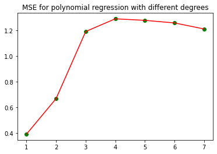

```python
number_degrees = [1,2,3,4,5,6,7]
plt_mean_absolute_error = []
x = health_train[potential_predictors]
y = health_train['life_expect']

for degree in number_degrees:

   poly_model = PolynomialFeatures(degree=degree)

   poly_x_values = poly_model.fit_transform(x)
   poly_x_train, poly_x_test, y_train, y_test = train_test_split(poly_x_values, y, test_size = 0.5, random_state = 4)
   poly_model.fit(poly_x_train, y_train)

   regression_model = LinearRegression()
   regression_model.fit(poly_x_train, y_train)
   y_pred = regression_model.predict(poly_x_test)

   plt_mean_absolute_error.append(mean_absolute_error(y_test, y_pred))

plt.scatter(number_degrees,plt_mean_absolute_error, color='green')
plt.plot(number_degrees,plt_mean_absolute_error, color='red')
plt.title('MSE for polynomial regression with different degrees')
print('Minimum MAE =', min(plt_mean_absolute_error))
```

According to the plot above, linear regression gives the best result, which is to be expected. As the degree value rises, the value of MA E increases until it reaches a plateau.

### More attempts

KNN Regression

```python
neigh = KNeighborsRegressor(n_neighbors=3)
cv = KFold(n_splits=10, random_state=0, shuffle=True)
scores = cross_val_score(neigh, x, y, scoring='neg_mean_absolute_error',
                         cv=cv, n_jobs=-1)
print('MAE for 12-fold cross validation of KNN regression',np.mean(np.absolute(scores)))
```

[output not shown]

```python
neigh.fit(health_train[potential_predictors], health_train['life_expect'])
print('Coefficient of determination of KNN Regression is', neigh.score(health_train[potential_predictors], health_train['life_expect']))
```

```
Coefficient of determination of KNN Regression is 0.9672250951291452
```

The best result so far!

Decision Tree

```
Minimum MAE = 0.72091836734694 was reached with maximum depth = 5
```

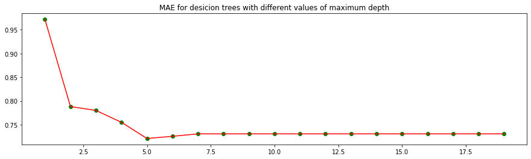

```python
x_train = health_train[potential_predictors][health_train.year==2018]
y_train = health_train['life_expect'][health_train.year==2018]
x_test = health_train[potential_predictors][health_train.year==2019]
y_test = health_train['life_expect'][health_train.year==2019]

max_depth = range(1,20)
plt_mean_absolute_error = []
for depth in max_depth:

   clf = tree.DecisionTreeRegressor(max_depth=depth, random_state=36).fit(x_train, y_train)
   y_pred = clf.predict(x_test)
   plt_mean_absolute_error.append(mean_absolute_error(y_test, y_pred))

plt.figure().set_figwidth(15)
plt.scatter(max_depth,plt_mean_absolute_error, color='green')
plt.plot(max_depth,plt_mean_absolute_error, color='red')
plt.title('MAE for desicion trees with different values of maximum depth')
print('Minimum MAE =', min(plt_mean_absolute_error),'was reached with maximum depth =',plt_mean_absolute_error.index(min(plt_mean_absolute_error))+1)
```

```python
tree = tree.DecisionTreeRegressor(max_depth=5, random_state=36)
cv = KFold(n_splits=10, random_state=0, shuffle=True)
scores = cross_val_score(tree, x, y, scoring='neg_mean_absolute_error',
                         cv=cv, n_jobs=-1)
print('MAE for 10-fold cross validation of Decision Tree with max depth=5',np.mean(np.absolute(scores)))
```

```
MAE for 10-fold cross validation of Decision Tree with max depth=5 0.5156772366522364
```

Better than tree trained without cross validation, but still worse than KNN.

### Ensemble Models

Random forest

```python
regr = RandomForestRegressor(n_estimators=100, max_depth=5, random_state=0)
cv = KFold(n_splits=12, random_state=0, shuffle=True)
scores = cross_val_score(regr, x, y, scoring='neg_mean_absolute_error',
                         cv=cv, n_jobs=-1)
print('MAE for 12-fold cross validation of random forest',np.mean(np.absolute(scores)))
```

```
MAE for 12-fold cross validation of random forest 0.4535804467077955
```

Gradient boosting

```python
model = XGBRegressor(n_estimators=100, max_depth=10)
cv = KFold(n_splits=8, random_state=1, shuffle=True)

scores = cross_val_score(model, x, y, scoring='neg_mean_absolute_error',
                         cv=cv, n_jobs=-1)

print('MAE for 8-fold cross validation of ',np.mean(np.absolute(scores)))
```

```
MAE for 8-fold cross validation of  0.4124258518218996
```

### Using state as a predictor

#### One Hot Encoding

```python
health = health_train.copy()
```

```python
X = health[['state',	'drinking',	'smoking',	'veggies',	'pneum_vaccine',	'obesity',	'lifetime_depression']]
Y = health['life_expect']
```

```python
from sklearn.preprocessing import OneHotEncoder
onehotencoder = OneHotEncoder(handle_unknown='ignore',sparse=False)
new_features = pd.DataFrame(onehotencoder.fit_transform(X[['state']]))
```

```python
X = pd.concat([X, new_features], axis=1, join='inner')
X.drop(columns=['state'], inplace=True)
```

```python
cv = KFold(n_splits=10, random_state=1, shuffle=True)

scores = cross_val_score(model, X, Y, scoring='neg_mean_absolute_error',
                         cv=cv, n_jobs=-1)

print('MAE for 10-fold cross validation of Linear Regression',np.mean(np.absolute(scores)))
```

[output not shown]

```python
model = XGBRegressor(n_estimators=100, max_depth=10)
cv = KFold(n_splits=8, random_state=1, shuffle=True)

scores = cross_val_score(model, X, Y, scoring='neg_mean_absolute_error',
                         cv=cv, n_jobs=-1)

print('MAE for 8-fold cross validation of ',np.mean(np.absolute(scores)))
```

```
MAE for 8-fold cross validation of  0.40043478378882835
```

```python
neigh = KNeighborsRegressor(n_neighbors=2)
cv = KFold(n_splits=10, random_state=3, shuffle=True)
scores = cross_val_score(neigh, X, Y, scoring='neg_mean_absolute_error',
                         cv=cv, n_jobs=-1)
print('MAE for 12-fold cross validation of KNN regression',np.mean(np.absolute(scores)))
```

[output not shown]

#### Binary Encoding

```python
!pip install category_encoders
import category_encoders as ce
```

```python
X = health[['state',	'drinking',	'smoking',	'veggies',	'pneum_vaccine',	'obesity',	'lifetime_depression']]
Y = health['life_expect']

ce_be = ce.BinaryEncoder()

# transform the data
data_binary = ce_be.fit_transform(X[['state']])
data_binary
```

|  | state_0 | state_1 | state_2 | state_3 | state_4 | state_5 |
| --- | --- | --- | --- | --- | --- | --- |
| 0 | 0 | 0 | 0 | 0 | 0 | 1 |
| 1 | 0 | 0 | 0 | 0 | 0 | 1 |
| 2 | 0 | 0 | 0 | 0 | 1 | 0 |
| 3 | 0 | 0 | 0 | 0 | 1 | 0 |
| 4 | 0 | 0 | 0 | 0 | 1 | 1 |
| ... | ... | ... | ... | ... | ... | ... |
| 94 | 1 | 1 | 0 | 0 | 0 | 0 |
| 95 | 1 | 1 | 0 | 0 | 0 | 1 |
| 96 | 1 | 1 | 0 | 0 | 0 | 1 |
| 97 | 1 | 1 | 0 | 0 | 1 | 0 |
| 98 | 1 | 1 | 0 | 0 | 1 | 0 |

99 rows × 6 columns

```python
X = pd.concat([X, data_binary], axis=1, join='inner')
X.drop(columns=['state'], inplace=True)
```

```python
neigh = KNeighborsRegressor(n_neighbors=2)
cv = KFold(n_splits=10, random_state=3, shuffle=True)
scores = cross_val_score(neigh, X, Y, scoring='neg_mean_absolute_error',
                         cv=cv, n_jobs=-1)
print('MAE for 12-fold cross validation of KNN regression',np.mean(np.absolute(scores)))
```

[output not shown]

## Bayesian Inferance

There aro some prerequisites for using Bayesian inference in this case.

- Small amount of data. We have only 99 rows in datset thus some outliers could lead to an incorrect fit. However, if we use a Bayesian approach, a prior distribution over the parameters can act as a regularization.
- Using prior information.
- Hierarchy in data.

Each state’s life expectancy comes from a distribution of life expectancy in some cluster of states defined by sociocultural factors, wealth, and so on. And the parameters of each cluster come from a more global distribution of life expectancy average values in the country. The hierarchical modelling has the advantage that even when clusters has small number of data points, you can still represent their features. Once more, using a hierarchical model rather than building distinct models for each cluster makes it more resistant to outliers and limited data.

### Simple linear regression

Firstly, let's make a simple Linear Regression using Bayesian approach to pick parameters of priors and to compare it with Linear Regression that uses mean least square method.

Distributions of independent variables:

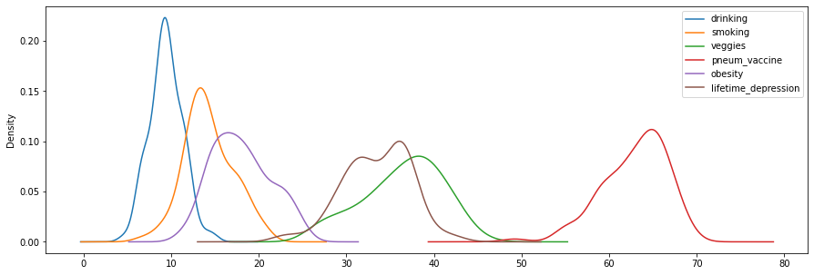

```python
health_train[potential_predictors].plot(kind='kde', figsize=(15,5))
```

Distribution of dependent variable:

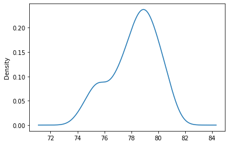

```python
health_train['life_expect'].plot(kind='kde')
```

According to the nature of the data, we can make an assumption of normally distributed variables (all kinds of variables in natural and social sciences are normally or approximately normally distributed). The plots above confirm it and give us information about statistical parameters of these distributions.

#### Defining and Fitting Model

```python
x_train, x_test, y_train, y_test = train_test_split(health_train.drop(columns=['life_expect','year']),
                                                    health_train['life_expect'])
state_id, states = pd.factorize(x_train.state)
coords = {
    'obs_id': np.arange(len(x_train)),
    'states': states
}
```

```python
with pm3.Model(coords=coords) as lin_model:
    # data containers
    X_drinking = pm3.Data("X_drinking", x_train['drinking'].values)
    X_smoking = pm3.Data("X_smoking", x_train['smoking'].values)
    X_veggies = pm3.Data("X_veggies", x_train['veggies'].values)
    X_obesity = pm3.Data("X_obesity", x_train['obesity'].values)
    X_depression = pm3.Data("X_depression", x_train['lifetime_depression'].values)
    y = pm3.Data('y', y_train)

    # Define priors
    intercept = pm3.Normal('Intercept', 5, 20)
    drinking_coeff = pm3.Normal('drinking',0, 4)
    smoking_coeff = pm3.Normal('smoking', 0, 4)
    veggies_coeff = pm3.Normal('veggies', 0, 4)
    obesity_coeff = pm3.Normal('obesity', 0, 4)
    depression_coeff = pm3.Normal('lifetime_depression', 0, 4)

    # Define likelihood
    sd = pm3.HalfCauchy('sigma', beta=5)
    lr = intercept + drinking_coeff * X_drinking + smoking_coeff * X_smoking +\
    veggies_coeff * X_veggies + obesity_coeff * X_obesity +\
    depression_coeff * X_depression

    likelihood = pm3.StudentT("lr", mu=lr, sigma=sd, nu=5, observed=y_train.values, dims='obs_id')
    #likelihood = pm3.Normal("lr", mu=lr, sigma=sd, observed=y_train.values, dims='obs_id')
    trace = pm3.sample(5000, tune=5000)

    prior_checks = pm3.sample_prior_predictive(samples=500)#, random_seed=rng)
    ppc = pm3.sample_posterior_predictive(trace)
```

100.00% [10000/10000 02:38<00:00 Sampling chain 0, 0 divergences]

100.00% [10000/10000 02:22<00:00 Sampling chain 1, 0 divergences]

```
WARNING:pymc3:The acceptance probability does not match the target. It is 0.6707178640522575, but should be close to 0.8. Try to increase the number of tuning steps.
ERROR:pymc3:The estimated number of effective samples is smaller than 200 for some parameters.
```

100.00% [10000/10000 00:13<00:00]

```python
pm3.model_to_graphviz(lin_model)
```

[figure not shown]

```
ERROR:arviz.data.io_pymc3_3x:Got error No model on context stack. trying to find log_likelihood in translation.
ERROR:arviz.data.io_pymc3_3x:Got error No model on context stack. trying to find log_likelihood in translation.
```

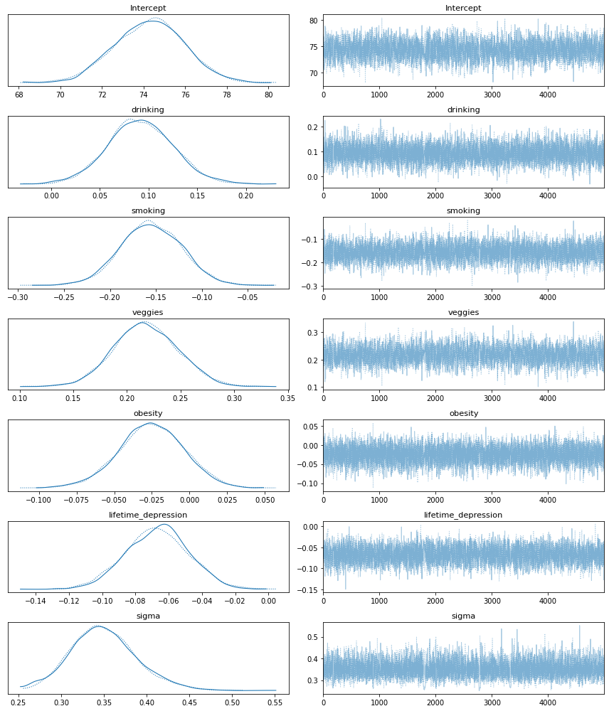

```python
az.plot_trace(trace)
plt.tight_layout()
```

Let's visualize the capability of the model to reproduce the patterns observed in the real data.

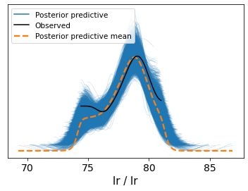

```python
az.plot_ppc(az.from_pymc3(posterior_predictive=ppc, model=lin_model))
```

The model appears to be rather effective at retrodicting the data.

```python
y_true = y_train.values
y_pred = ppc['lr']
az.r2_score(y_true, y_pred)
```

```
r2        0.855073
r2_std    0.027880
dtype: float64
```

```python
az.summary(trace)
```

```
ERROR:arviz.data.io_pymc3_3x:Got error No model on context stack. trying to find log_likelihood in translation.
```

|  | mean | sd | hdi_3% | hdi_97% | mcse_mean | mcse_sd | ess_bulk | ess_tail | r_hat |
| --- | --- | --- | --- | --- | --- | --- | --- | --- | --- |
| Intercept | 74.282 | 1.673 | 71.152 | 77.356 | 0.030 | 0.021 | 3183.0 | 3577.0 | 1.0 |
| drinking | 0.092 | 0.034 | 0.029 | 0.156 | 0.001 | 0.000 | 4406.0 | 3344.0 | 1.0 |
| smoking | -0.155 | 0.033 | -0.217 | -0.093 | 0.001 | 0.000 | 4189.0 | 5201.0 | 1.0 |
| veggies | 0.218 | 0.030 | 0.164 | 0.276 | 0.001 | 0.000 | 3045.0 | 3254.0 | 1.0 |
| obesity | -0.025 | 0.022 | -0.066 | 0.015 | 0.000 | 0.000 | 6768.0 | 5991.0 | 1.0 |
| lifetime_depression | -0.067 | 0.019 | -0.102 | -0.032 | 0.000 | 0.000 | 4771.0 | 4899.0 | 1.0 |
| sigma | 0.350 | 0.039 | 0.280 | 0.427 | 0.001 | 0.001 | 2085.0 | 886.0 | 1.0 |

The r_hat statistics are equal to 1, which indicates the convergence of the model. The intercept value is close to the average life expectancy in the country, like in the regression model that uses the square method.

#### Generating Out-Of-Sample Predictions

```python
with lin_model:
    pm3.set_data({'X_drinking' : x_test['drinking'].values,
                 'X_smoking' : x_test['smoking'].values,
                 'X_veggies' : x_test['veggies'].values,
                 'X_obesity' : x_test['obesity'].values,
                 'X_depression' : x_test['lifetime_depression'].values,
                })
    post_pred = pm3.sample_posterior_predictive(trace, samples=3000)
```

100.00% [3000/3000 00:08<00:00]

MAE of Bayesian Linear Regression

```python
y_pred = np.mean(post_pred['lr'], axis=0)
print(mean_absolute_error(y_test, y_pred))
```

```
0.36543763288889203
```

### Hierarchical regression

```python
x_train, x_test, y_train, y_test = train_test_split(health_train.drop(columns=['life_expect','year']),
                                                    health_train['life_expect'], test_size=0.3)
```

```python
states_id, state_names = pd.factorize(x_train['state'], sort=True)
coords = {
    'obs_id': range(len(x_train)),
    'states': state_names,
}
with pm3.Model(coords=coords) as hierarchical_model:
    # data containers
    X_drinking = pm3.Data("X_drinking", x_train['drinking'].values)
    X_smoking = pm3.Data("X_smoking", x_train['smoking'].values)
    X_veggies = pm3.Data("X_veggies", x_train['veggies'].values)
    X_obesity = pm3.Data("X_obesity", x_train['obesity'].values)
    X_depression = pm3.Data("X_depression", x_train['lifetime_depression'].values)
    y = pm3.Data('y', y_train)
    state_idx = pm3.Data('state_idx', states_id, dims='obs_id')
    #states = pm3.Data('states', states, dims='obs_id')

    # hyper-priors
    state_mean = pm3.Normal('state_mean', mu=0.0001, sigma=10.0)
    state_sigma = pm3.Exponential("state_sigma", 1.0)

    # priors
    intercept = pm3.Normal('Intercept', 10, 30)
    state = pm3.Normal('state', mu=state_mean, sigma=state_sigma, dims=('states'))

    drinking_coeff = pm3.Logistic('drinking',0, 4)
    smoking_coeff = pm3.Logistic('smoking', 0, 4)
    veggies_coeff = pm3.Logistic('veggies', 0, 4)
    obesity_coeff = pm3.Logistic('obesity', 0, 4)
    depression_coeff = pm3.Logistic('lifetime_depression', 0, 4)
    #state_coeff = pm3.Logistic('state_coeff', 0, 4)
    '''
    drinking_coeff = pm3.Normal('drinking',0, 5)
    smoking_coeff = pm3.Normal('smoking', 0, 5)
    veggies_coeff = pm3.Normal('veggies', 0, 5)
    obesity_coeff = pm3.Normal('obesity', 0, 5)
    depression_coeff = pm3.Normal('lifetime_depression', 0, 5)
    #state_coeff = pm3.Normal('state_coeff', 0, 20)
    '''
    # Model
    mu = intercept + state[state_idx] + (drinking_coeff * X_drinking + smoking_coeff * X_smoking +\
    veggies_coeff * X_veggies + obesity_coeff * X_obesity +\
    depression_coeff * X_depression)

    sd = pm3.HalfCauchy('sigma', 2.0)
    # Likelihood
    observation = pm3.StudentT('obs', mu=mu, sigma=sd, nu=25, observed=y, dims='obs_id')

    trace2 =  pm3.sample(7000, tune=7000)
    prior_checks = pm3.sample_prior_predictive(samples=100)
    ppc2 = pm3.sample_posterior_predictive(trace2)
```

50.81% [7113/14000 03:24<03:17 Sampling chain 0, 0 divergences]

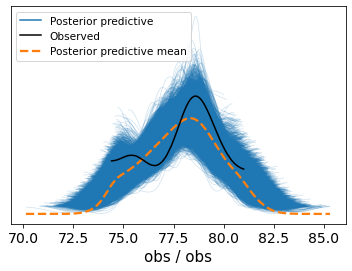

```python
az.plot_ppc(az.from_pymc3(posterior_predictive=ppc2, model=hierarchical_model))
```

```python
y_true = y_train.values
y_pred = ppc2['obs']
az.r2_score(y_true, y_pred)
```

```
r2        0.893997
r2_std    0.023653
dtype: float64
```

```python
az.summary(trace2)
```

[output not shown]

```python
states_id, state_names = pd.factorize(x_test['state'], sort=True)
with hierarchical_model:
    pm3.set_data({'X_drinking' : x_test['drinking'].values,
                 'X_smoking' : x_test['smoking'].values,
                 'X_veggies' : x_test['veggies'].values,
                 'X_obesity' : x_test['obesity'].values,
                 'X_depression' : x_test['lifetime_depression'].values,
                 'state_idx' : states_id
                })
    hier_pred = pm3.sample_posterior_predictive(trace2, samples=3000)
```

100.00% [3000/3000 00:35<00:00]

MAE of Bayesian Hierarchical Regression

```python
y_pred = np.mean(hier_pred['obs'], axis=0)
print(mean_absolute_error(y_test, y_pred))
```

```
0.3472494221698175
```